# Normalization: A pipeline to analyse time-course gene expression data

## Pre-processing and normalization

The micro-array data were obtained from NCBI Gene Expression Omnibus (GEO), with accession number GSE63786. The dataset has a total of 209 samples, with 45018 probes (1 sample was removed by the authors prior to uploading the dataset on GEO).

Note that in the following, we assume that the user has access to a data folder `data/shoemaker2015/rawdata`, containing the microarray data.

```r
data_dir = "data/shoemaker2015/rawdata"
```

Given the source and a `Targets.txt` structured as follows, microarray can be loaded thanks to the limma library.

```
FileName
GSM1557140_AR0313_043raw.txt.gz
GSM1557141_AR0313_044raw.txt.gz
GSM1557142_AR0313_045raw.txt.gz
GSM1557143_AR0313_055raw.txt.gz
GSM1557144_AR0313_056raw.txt.gz
GSM1557145_AR0313_057raw.txt.gz
GSM1557146_AR0313_058raw.txt.gz
GSM1557147_AR0313_059raw.txt.gz
```

```r
targets = limma::readTargets()
RG = limma::read.maimages(
  targets, source="agilent",
  path=data_dir,
  other.columns="gIsWellAboveBG",
  green.only=TRUE)
```

The normalization strategy we apply here relies on `limma` and is as follows:

- First, normalize probe intensity using background information using the “norm-exponential” strategy.
- Then normalize across micro-arrrays using quantile normalization.

```r
# Perform background correction using norm-exponential strategy and normalize
# across samples using quantile normalization.
RG = limma::backgroundCorrect(RG, method="normexp")
RG.q = limma::normalizeBetweenArrays(RG, method="quantile")
```

Plotting the smoothed empirical densities of the probe values before normalization shows considerable variations betweens arrays. Once the data has been normalized across array using quantile normalization, the smoothed empirical densities of each sample perfectly overlap.

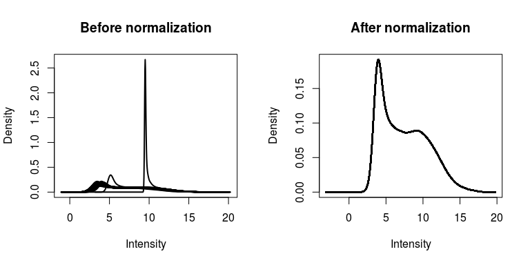

```r
# Plot the densities of the probes before and after normalization.
par(mfrow=c(1, 2))
limma::plotDensities(RG, col="black", legend=FALSE,
             main="Before normalization")
limma::plotDensities(RG.q, col="black", legend=FALSE,
             main="After normalization")
```

We then clean up the names of each gene and each sample to match the original data. Finally, we further filter out probes based on the following criteria: (1) removing the 1486 control probes; (2) removing 4823 low-expressed genes.

```r
sample_names = sapply(strsplit(colnames(RG.q), "_"), .subset2,  1)
colnames(RG.q) = sample_names
row.names(RG.q) = make.names(RG$genes$SystematicName, unique=TRUE)
idx_to_keep = which(
  !(RG$genes$Systematic %in% c("DarkCorner", "GE_BrightCorner",
                   "NegativeControl")))

data = RG.q[idx_to_keep,]

# Filter out control probes.
control_probes = data$genes[, "ControlType"] == 1
is_expressed = rowSums(data$other$"gIsWellAboveBG" > 0) >= 4

data = data[!control_probes & is_expressed, ]$E
```

Now that we have normalized and filtered the gene expressions, let’s load the metadata. The package `moanin` contains the normalized data and meta of (Shoemaker 2015).

```r
# Now load in the metadata
data(shoemaker2015)
meta = shoemaker2015$meta
data = shoemaker2015$data
```

## Exploratory analysis and quality control

Plotting the smoothed empirical densities of probe values for each sample and estimating the variations across samples before and after normalization is a first quality control step. Typically, two other quality control and exploratory analysis steps are also performed before and after normalization: (1) low dimensionality embedding of the samples; (2) correlation plots between each samples. In both cases, we expect a strong biological signal, while replicate samples should be strongly clustered or correlated with one another.

Before performing any additional exploratory analysis, let us only keep highly variable genes: we keep for this step only the top 50% most variable genes.

```r
variance_cutoff = 0.5
variance_per_genes = apply(data, 1, mad)
min_variance = stats::quantile(variance_per_genes, c(variance_cutoff))
data = data[variance_per_genes > min_variance,]
```

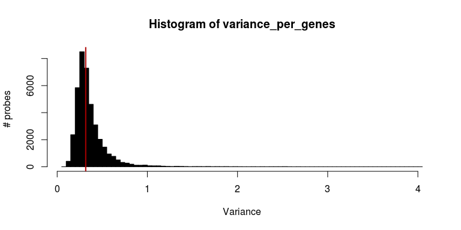

Let us first perform the PCA analysis. Here, we perform a PCA of rank 3 of the centered and scaled gene expression data.

```r
# Reorder genes on condition, time, and replicate

pca_data = stats::prcomp(t(data), rank=3, center=TRUE, scale=TRUE)
percent_var = round(100 * attr(pca_data, "percentVar"))
```

We then plot the two first components, and color each sample by (1) its condition; (2) its sampling time. We use different markers for each replicate. We also plot the second and third components in the second row.

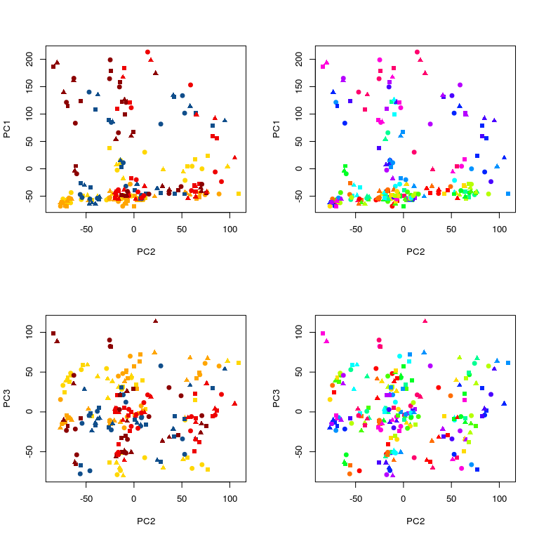

```r
graphics::par(mfrow=c(2, 2))
graphics::plot(
    pca_data$x[, "PC2"], pca_data$x[, "PC1"],
    col=ann_colors$Group[meta$Group],
    pch=ann_markers$Replicate[as.factor(meta$Replicate)],
    xlab="PC2", ylab="PC1")
graphics::plot(
    pca_data$x[, "PC2"], pca_data$x[, "PC1"],
    col=ann_colors$Timepoint[as.factor(meta$Timepoint)],
    pch=ann_markers$Replicate[as.factor(meta$Replicate)],
    xlab="PC2", ylab="PC1")

graphics::plot(
    pca_data$x[, "PC2"], pca_data$x[, "PC3"],
    col=ann_colors$Group[meta$Group],
    pch=ann_markers$Replicate[as.factor(meta$Replicate)],
    xlab="PC2", ylab="PC3")
graphics::plot(
    pca_data$x[, "PC2"], pca_data$x[, "PC3"],
    col=ann_colors$Timepoint[as.factor(meta$Timepoint)],
    pch=ann_markers$Replicate[as.factor(meta$Replicate)],
    xlab="PC2", ylab="PC3")
```

Then, we plot the pearson correlation across each samples. We order the samples by their Group (treatment) and Timepoint (the time of sampling). Additionally, in this example, we order each treatment by strength of the pathogenicity of the treatment: Control, Kawasaki, California, low dose of Vietnam, then high dose of Vietnam.

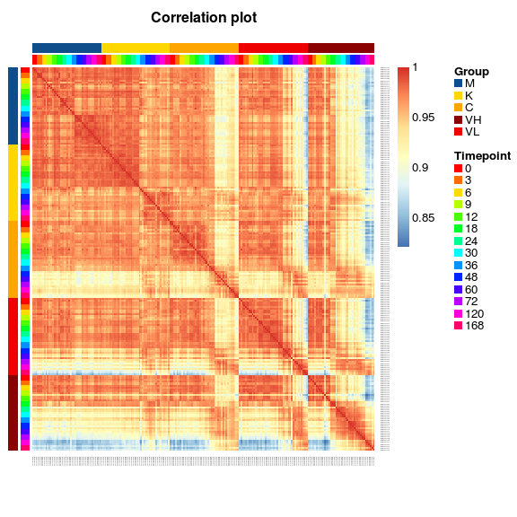

```r
library(NMF)

# Reorder the conditions such that:
#   - Control is before any influenza treatment
#   - Each treatment is ordered from low to high pathogeny
meta$Group = factor(meta$Group, levels(meta$Group)[c(3, 2, 1, 5, 4)])

# Reorder genes on condition, time, and replicate
ord = order(
  meta$Group,
  meta$Timepoint,
  meta$Replicate)
data = data[, ord]
meta = meta[ord, ]

data_corr = stats::cor(data, method="pearson")

meta$Timepoint = as.factor(meta$Timepoint)
NMF::aheatmap(
    data_corr,
    Colv=NA, Rowv=NA,
    annCol=meta[, c("Group", "Timepoint")],
    annRow=meta[, c("Group", "Timepoint")],
    annLegend=TRUE,
    annColors=ann_colors,
    main="Correlation plot")
```

We can already see interesting patterns emerging from the correlation plot. First, the cross-correlation amongst samples taking from the control mice is higher than the cross correlation amongst the rest of the treatments. Second, the influenza-infected mice midly react until time point 36. Third, the less pathogenic the strain is, the closer the samples are to the control condition. Fourth, the Vietnam samples at time point 120 and 168 are the one that are the most different from control samples.

# References

Shoemaker, S. AND Eisfeld, J. E. AND Fukuyama. 2015. “An Ultrasensitive Mechanism Regulates Influenza Virus-Induced Inflammation.” *PLoS Pathogens* 11 (6): 1–25.